### Utah Lake Algal Communities

##### Ranae Zauner, Spring 2018

The data for this project came from Rushforth Phycology. Samples were collected by the Utah Department of Water quality. It was given to me in excel files (one for each month), and look a significant amount of manipulation to prepare for analysis with the Vegan package. The code for this is happening in the background.

At this point, df and meta_edit are nearly ready for analysis. A couple more things need to be done. First:

#### Convert date into date format readable by R

```r
# levels(meta_edit$Site.Name)
# levels(meta_edit$Date)

meta_edit$Date = as.character(meta_edit$Date)
meta_edit$Date = as.Date(meta_edit$Date, format = "%m/%d/%Y")
```

Now! “df” and “meta_edit” are ready for Vegan!

#### Lets see what Vegan can do with this data.

First, let’s create additional data frames with data presented in different ways for various analysis.

```r
# glimpse(dat)
# row.names(df)=df$`RP.Lab.ID`
df$`RP.Lab.ID`=NULL

df_pa = decostand(df, "pa") #for presence/absence
df_rounded = as.data.frame(apply(df,2,round)) # Round counts to integers

# remove bummer rows
good_rows = row.names(df) %in% meta_edit$RP.Lab.ID

df_pa = df_pa[good_rows,]
```

#### Look at Nonmetric Multidimensional Scaling.

```r
nmds = metaMDS(df_pa)
```

```
## *** No convergence -- monoMDS stopping criteria:
##     20: stress ratio > sratmax
```

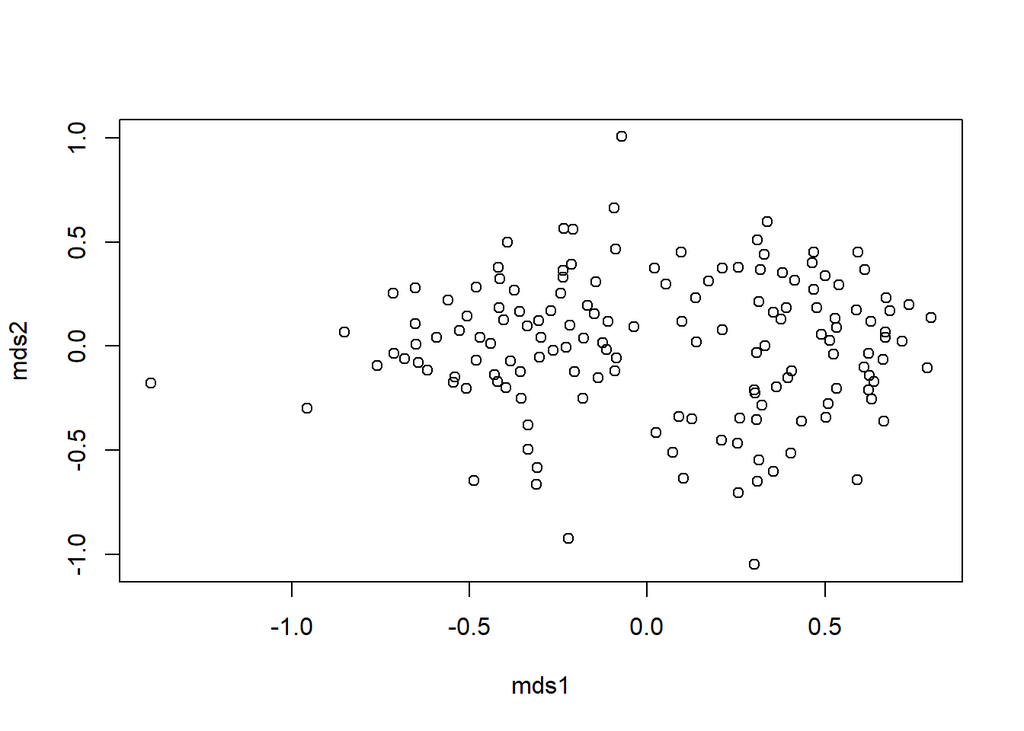

```r
mds1 = nmds$points[,1]
mds2 = nmds$points[,2]

NMDS = data.frame(mds1 = mds1, mds2 = mds2, site = meta_edit$Site.Name, Date = meta_edit$Date, Month = months(meta_edit$Date))

plot(mds1,mds2)
```

This isn’t a terrible plot, but it could be better.

#### Make a pretty ggplot with NMDS:

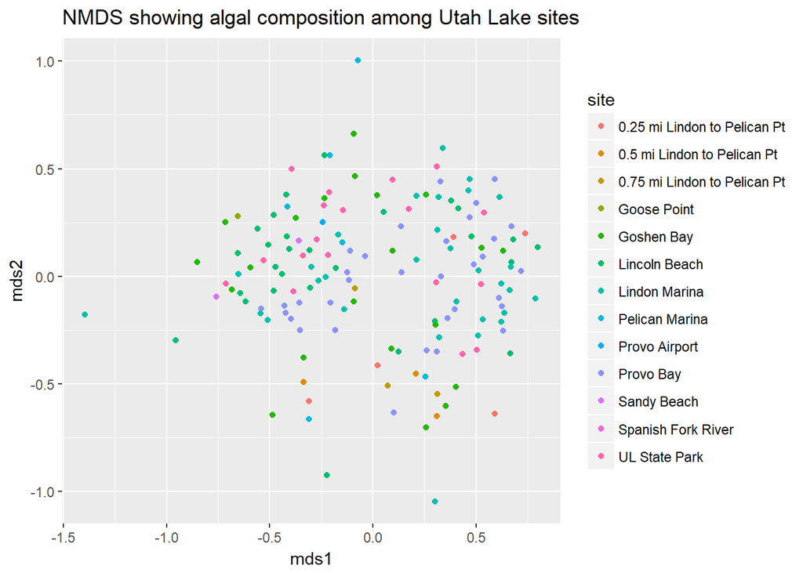

```r
plot1 = ggplot(NMDS, aes(x=mds1, y=mds2, color= site, frame = Month)) +
  geom_point() +
  labs(title = "NMDS showing algal composition among Utah Lake sites")

plot1
```

```
## Executing:
## "convert -loop 0 -delay 250 Rplot1.png Rplot2.png Rplot3.png
##     Rplot4.png Rplot5.png Rplot6.png Rplot7.png Rplot8.png
##     "gga_plot1.gif""
```

```
## Output at: gga_plot1.gif
```

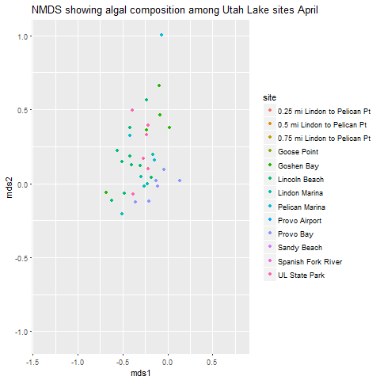

```r
meta_edit$month = months(meta_edit$Date)

meta_edit$month = factor(meta_edit$month)
levels(meta_edit$month) = c("January", "February", "March", "April","May","June","July", "August")

setwd("c:/Users/Ranae/Desktop/Utah_Lake_Project/")
gga_plot1 = gganimate(plot1, interval = 2.5, "gga_plot1.gif")
```

#### What about a simple look at diversity of each sample over time?

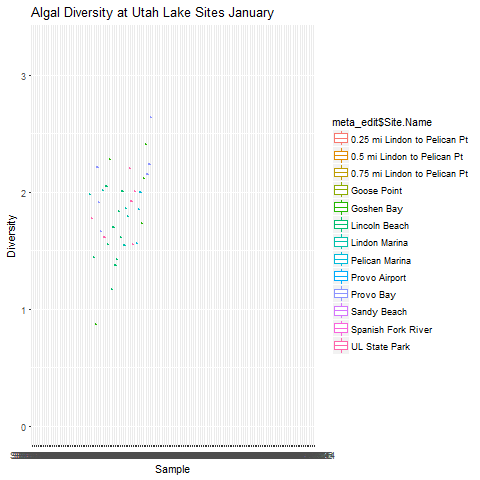

```r
df = df[good_rows,]


plot2 = ggplot(mapping = aes(x=meta_edit$RP.Lab.ID, y=diversity(df), color=meta_edit$Site.Name, frame = (meta_edit$month), cumulative = TRUE )) +
  geom_boxplot() +
  labs(y = "Diversity", x = "Sample", title = "Algal Diversity at Utah Lake Sites")


gga_plot2 = gganimate(plot2, interval = 2.5, "gga_plot2.gif")
```

Not bad, but a better way to look at this might be a Shannon Index to characterize species diversity (accounts for species abundance and evenness).

#### Shannon Index

```r
specnumber(df, groups = meta_edit$Site.Name)
```

```
## 0.25 mi Lindon to Pelican Pt  0.5 mi Lindon to Pelican Pt
##                           55                           24
## 0.75 mi Lindon to Pelican Pt                  Goose Point
##                           26                            4
##                   Goshen Bay                Lincoln Beach
##                           61                           75
##                Lindon Marina               Pelican Marina
##                           89                           28
##                Provo Airport                    Provo Bay
##                            8                           78
##                  Sandy Beach           Spanish Fork River
##                           10                            3
##                UL State Park
##                           58
```

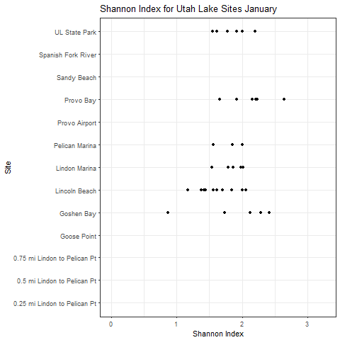

```r
div1 = diversity(df, index = "shannon")
meta_edit$Shannon = diversity(df, index = "shannon")

plot3 = ggplot(df, aes(y = meta_edit$Site.Name, x=div1, frame = (meta_edit$month))) +
  geom_point() +
  theme_bw() +
  labs(y = "Site", x = "Shannon Index", title = "Shannon Index for Utah Lake Sites")

gga_plot3 = gganimate(plot3, interval = 2.5, "gga_plot3.gif")
```

#### Lets look at Ordination:

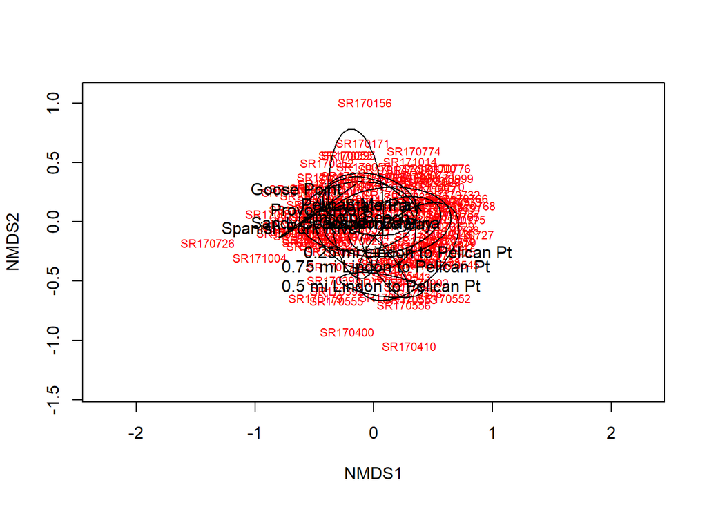

```r
ordiplot(nmds, type = "n") # Sets up the plotting area
orditorp(nmds,display="sites",col="red",air=0.01) # Adds the samples in ordination space
ordiellipse(nmds, groups = meta_edit$Site.Name, label = TRUE) # Calculates the centroid and 95% C.I. of each treatment group
```

Whoa! We can do better.

#### Ordination in ggplot

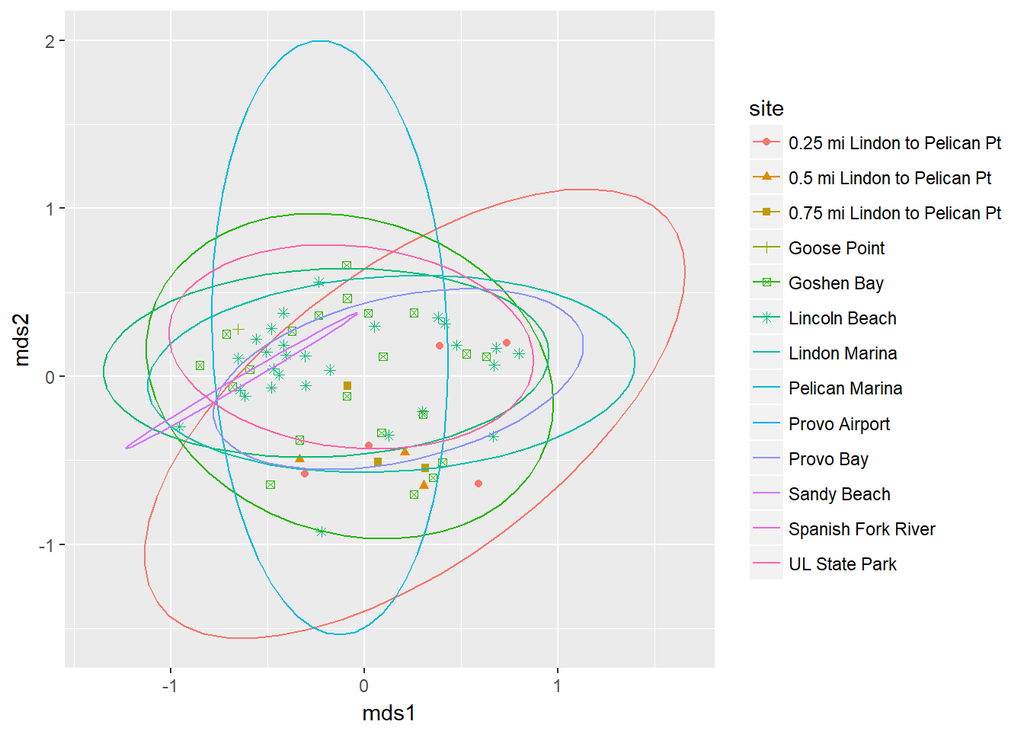

```r
ggplot(NMDS, aes(x=mds1,y=mds2,color=site)) +
  geom_point(aes(shape=site) ) +
  stat_ellipse()
```

No real visisble differences in the sites, what does ANOVA say?

#### Adonis (Permutational Multivariate Analysis of Variance Using Distance Matrices)

```r
adonis(df_pa ~ meta_edit$Site.Name)
```

```
##
## Call:
## adonis(formula = df_pa ~ meta_edit$Site.Name)
##
## Permutation: free
## Number of permutations: 999
##
## Terms added sequentially (first to last)
##
##                      Df SumsOfSqs MeanSqs F.Model      R2 Pr(>F)
## meta_edit$Site.Name  12     3.616 0.30134  1.6689 0.12136  0.001 ***
## Residuals           145    26.181 0.18056         0.87864
## Total               157    29.797                 1.00000
## ---
## Signif. codes:  0 '***' 0.001 '**' 0.01 '*' 0.05 '.' 0.1 ' ' 1
```

Adonis stays this is important, but can you trust it? The ordination chart suggests this is more about due to a lack of data points.

#### Species Accumulation curve

```r
spe <- specaccum(df)
```

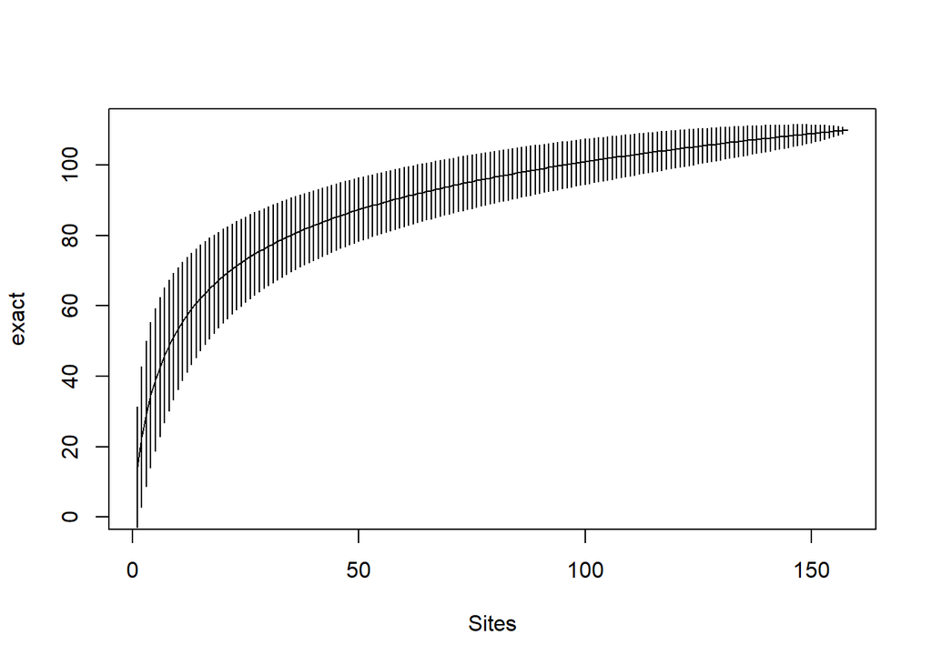

```r
plot(spe)
```

#### Fisher Alpha value

```r
meta_edit$Fisher = fisher.alpha(df_pa)
```

If would be interesting to map these sites for one more analysis.

#### GPS points were not provided based on this dataset, so grab from google.

```r
library(ggmap)
library(leaflet)
library(sp)
library(magrittr)
library(shiny)

#Add GPS points to meta_edit
meta_edit$lat = plyr::mapvalues(meta_edit$Site.Name, from = levels(meta_edit$Site.Name), to = c("40.325437","40.322984","40.320503","40.255507","40.007928","40.141172",
                                                                                                "40.327676","40.267794","40.206524","40.198590","40.168882","40.166738","40.237354"))
meta_edit$lon = plyr::mapvalues(meta_edit$Site.Name, from = levels(meta_edit$Site.Name), to = c("-111.770932","-111.774439","-111.777657","-111.855231","-111.912158","-111.801620",
                                                                                                "-111.765439","-111.848799","-111.7302345","-111.665206","-111.745437","-111.748290","-111.741528"))


meta_edit$lat = as.numeric(as.character(meta_edit$lat))
meta_edit$lon = as.numeric(as.character(meta_edit$lon))
```

#### Make a map!

```r
map <- leaflet(meta_edit) %>%
  addCircles(lng = meta_edit$lon, lat = meta_edit$lat)%>%
  addTiles() %>%
  addMarkers(lng=-111.765439,lat=40.327676, popup = "Lindon Marina")%>%
  addMarkers(lng=-111.848799,lat=40.267794, popup = "Pelican Point")

map
```

[interactive chart not shown]

Not bad! How about a map with more information?

```r
qpal <- colorQuantile("YlGnBu", meta_edit$Shannon, n = 4)

#Change Sig Figs of Shannon for popups:
meta_edit$Shannon_Sig = signif(meta_edit$Shannon,4)

map1 <- leaflet(meta_edit) %>%
  addTiles(group = "Topo")%>%
  addProviderTiles("Esri.WorldTopoMap", group = "Topo")%>%
  addCircleMarkers(lng = meta_edit$lon, lat = meta_edit$lat, popup = paste("Site: ", meta_edit$Site.Name, "<br>", "Shannon Index: ",
                                                                           meta_edit$Shannon_Sig),
                   weight = 1, radius = 12, color = ~qpal(meta_edit$Shannon), stroke = FALSE, fillOpacity = 0.5, group = "circles") %>%
  addLegend(pal = qpal, values = ~Shannon, group = "circles", position = "bottomright", title = "Shannon Index")%>%
  addMiniMap(position = "topright")%>%
  addScaleBar(position = "topleft")

map1
```

[interactive chart not shown]

While leaflet seems pretty wide spread, it wasn’t very well documented. Here’s a few things I learned the hard way: *In order to use another map, it has to be assigned to a group. + See: addProviderTiles(“Esri.WorldTopoMap”, group = “Topo”)* Colors had to be assigned to palets, that could then be called in leaflet + qpal <- colorQuantile(“YlGnBu”, meta_edit$Shannon, n = 4)